# Lista - AP2 - Identificação e Modelagem de Processos Estacionários

## Visualizando FAC e FACP:

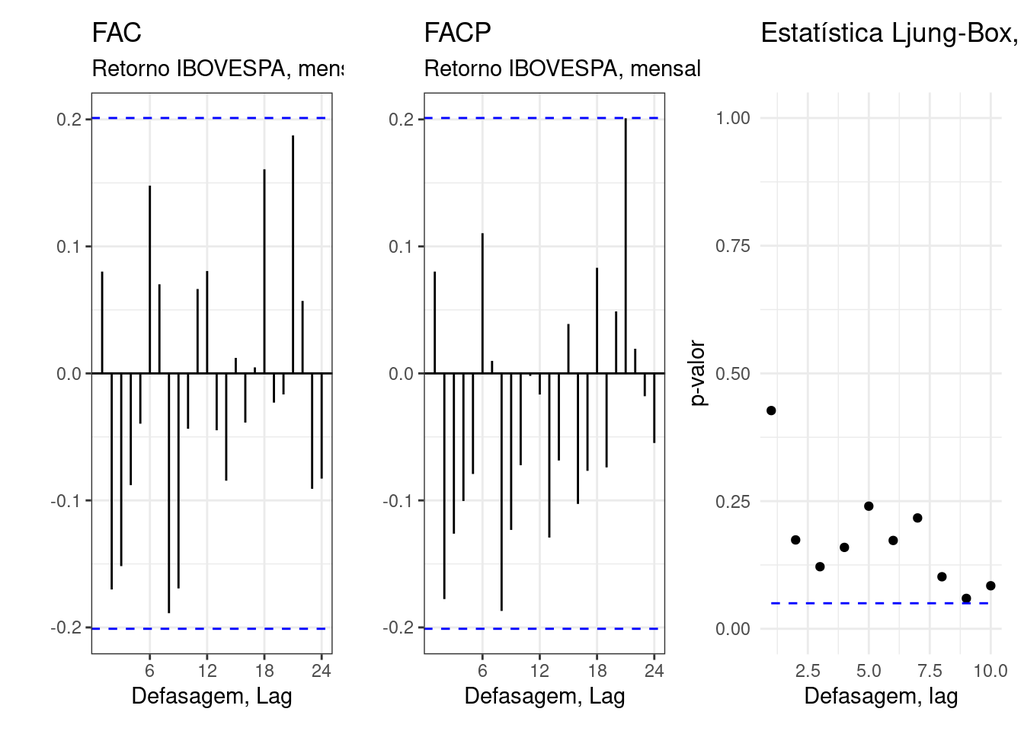

FAC vs FACP, por defasagem

|  | 1 | 2 | 3 | 4 | 5 | 6 | 7 | 8 | 9 | 10 |
| --- | --- | --- | --- | --- | --- | --- | --- | --- | --- | --- |
| FAC | 0.0802 | -0.1701 | -0.1517 | -0.0880 | -0.0396 | 0.1479 | 0.0702 | -0.1888 | -0.1693 | -0.0436 |
| FACP | 0.0802 | -0.1777 | -0.1262 | -0.1005 | -0.0792 | 0.1104 | 0.0099 | -0.1870 | -0.1233 | -0.0723 |
| Ljung–Box | 0.6303 | 3.4975 | 5.8039 | 6.5875 | 6.7478 | 9.0114 | 9.5270 | 13.3013 | 16.3713 | 16.5772 |
| p-valor | 0.4272 | 0.1740 | 0.1216 | 0.1594 | 0.2401 | 0.1729 | 0.2170 | 0.1019 | 0.0595 | 0.0843 |

## Diagnostico de residuos:

FAC vs FACP dos Resíduos, por defasagem

[output not shown]

Testes TS

1. Teste de Normalidade do resíduos:

   1.1 Kernel(ê)

Se: e ~ Ruído Branco (ê: Padronizado)

2. Teste de Normalidade dos momentos:

   2.1 Jarque-Bera

Se: Assimetria = 0 Se: Excesso de Cortose = 0

```
##                 Dados
## nobs        95.000000
## NAs          0.000000
## Minimum     -0.299044
## Maximum      0.169673
## 1. Quartile -0.029127
## 3. Quartile  0.061086
## Mean         0.011400
## Median       0.007026
## Sum          1.082956
## SE Mean      0.006984
## LCL Mean    -0.002467
## UCL Mean     0.025266
## Variance     0.004634
## Stdev        0.068071
## Skewness    -0.791663
## Kurtosis     3.152422
```

```
##
## Title:
##  Jarque - Bera Normalality Test
##
## Test Results:
##   STATISTIC:
##     X-squared: 52.9331
##   P VALUE:
##     Asymptotic p Value: 3.204e-12
```

```
##
##  Box-Ljung test
##
## data:  y^2
## X-squared = 0.54876, df = 2, p-value = 0.76
## alternative hypothesis: y is heteroscedastic
```

#### Visualização, tabelas, AIC e Diagnostico Resíduos

2. Plote os gráficos de FAC e FACP.

#### FAC e FACP

3. Estime os coeficientes e apresente os modelos. (Utilize software apropriado)

### IPCA

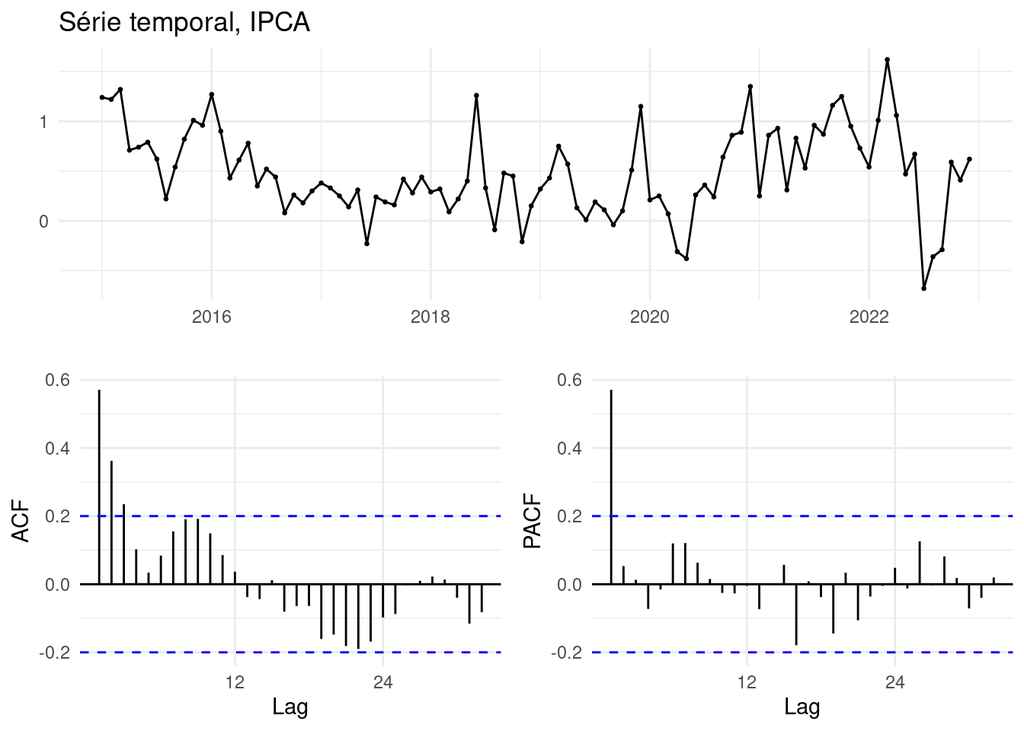

1. Realize os testes de identificação, assim como os de Critério de Informação e Diagnóstico de Resíduos.
2. Plote os gráficos de FAC e FACP.
3. Estime os coeficientes e apresente os modelos. (Utilize software apropriado)

### Credito

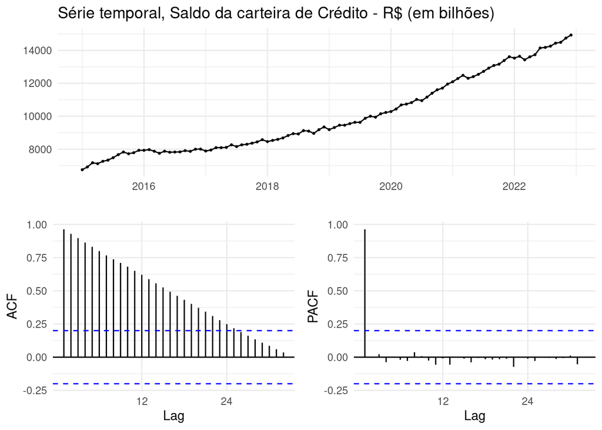

1. Realize os testes de identificação, assim como os de Critério de Informação e Diagnóstico de Resíduos.
2. Plote os gráficos de FAC e FACP.
3. Estime os coeficientes e apresente os modelos. (Utilize software apropriado)

### AÇÃO

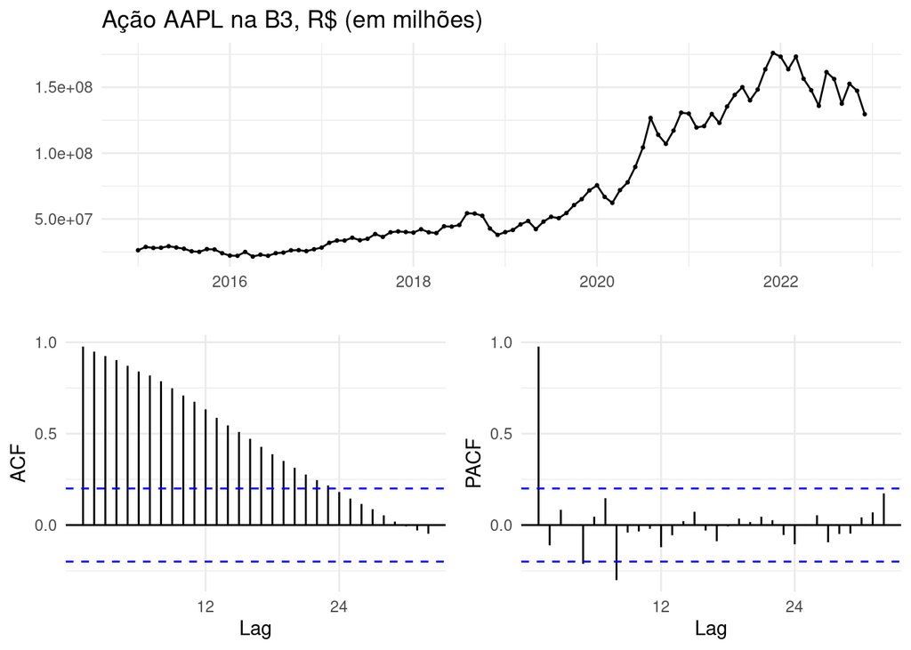

1. Realize os testes de identificação, assim como os de Critério de Informação e Diagnóstico de Resíduos.
2. Plote os gráficos de FAC e FACP.
3. Estime os coeficientes e apresente os modelos. (Utilize software apropriado)

### Retorno da AÇÃO

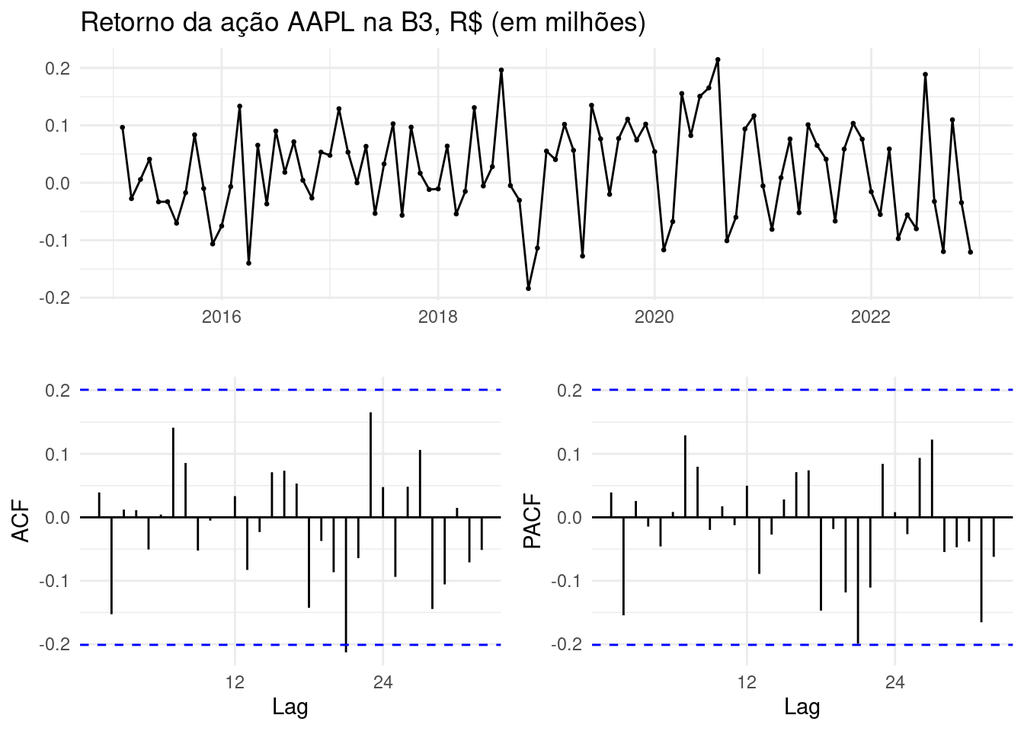

1. Realize os testes de identificação, assim como os de Critério de Informação e Diagnóstico de Resíduos.
2. Plote os gráficos de FAC e FACP.
3. Estime os coeficientes e apresente os modelos. (Utilize software apropriado)
4. O preço do ativo pode ser modelado por um processo estacionário? Se não, justifique e verifique se o retorno desse ativo é um processo estacionário.

### Questão 3:

Utilizando as séries disponibilizadas no arquivo “AP2.xlsx”, faça para cada uma das séries o que se pede:

### Definindo as séries temporais

Visualizando as Séries:

### Série Q3.1

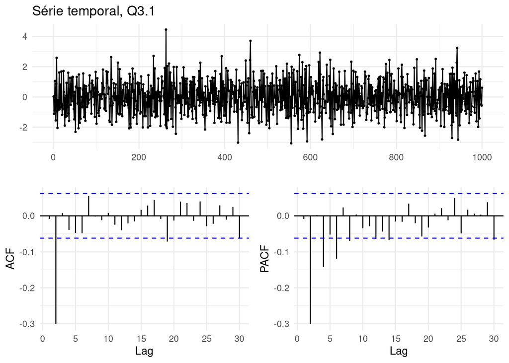

### Série Q3.2

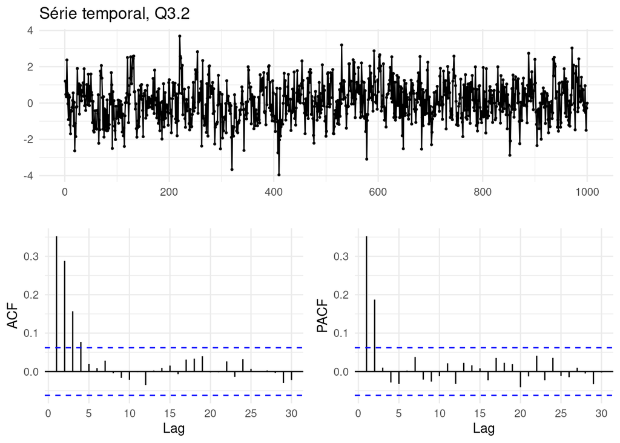

### Série Q3.3

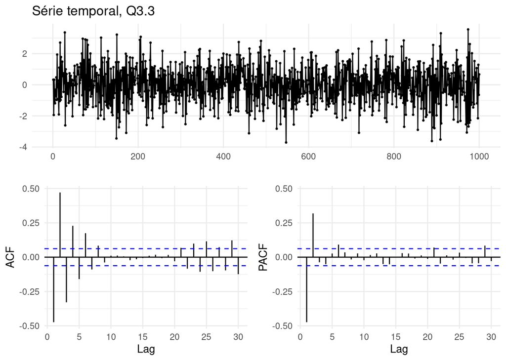

### Série Q3.4

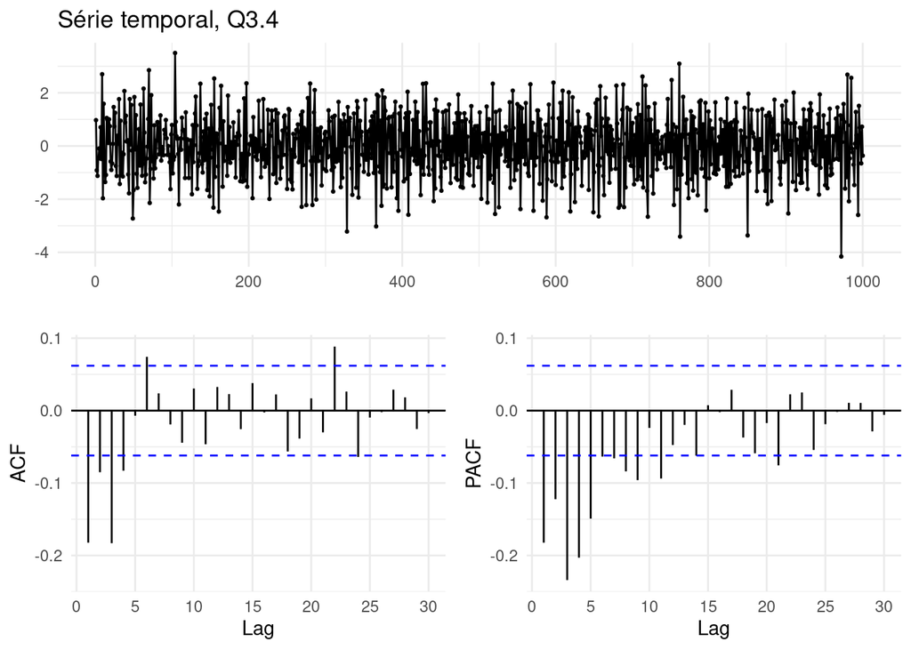

### Série Q3.5

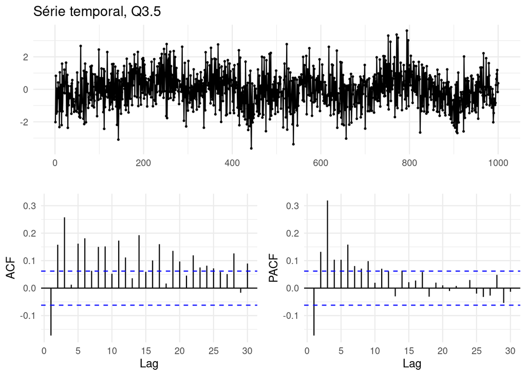

1. Realize os testes de identificação, assim como os de Critério de Informação e Diagnóstico de Resíduos.

arima; AIC; tsdiag(arima)

2. Plote os gráficos de FAC e FACP. ggtsdisplay;
3. Estime os coeficientes e apresente os modelos. (Utilize software apropriado) arima$coef; coeftest;